# Machine Learning for Banking

**About**:Have you ever wondered how lenders use various factors such as credit score, annual income, the loan amount approved, tenure, debt-to-income ratio etc. and select your interest rates?

The process, defined as ‘risk-based pricing’, uses a sophisticated algorithm that leverages different determining factors of a loan applicant. Selection of significant factors will help develop a prediction algorithm which can estimate loan interest rates based on clients’ information. On one hand, knowing the factors will help consumers and borrowers to increase their credit worthiness and place themselves in a better position to negotiate for getting a lower interest rate. On the other hand, this will help lending companies to get an immediate fixed interest rate estimation based on clients information. Here, your goal is to use a training dataset to predict the loan rate category (1 / 2 / 3) that will be assigned to each loan in our test set.

You can use any combination of the features in the dataset to make your loan rate category predictions. Some features will be easier to use than others.

**Attribute Information**:

- Loan_ID:A unique id for the loan.
- Loan_Amount_Requested:The listed amount of the loan applied for by the borrower.
- Length_Employed:Employment length in years
- Home_Owner:The home ownership status provided by the borrower during registration. Values are: Rent, Own, Mortgage, Other.
- Annual_Income:The annual income provided by the borrower during registration.
- Income_Verified:Indicates if income was verified, not verified, or if the income source was verified
- Purpose_Of_Loan:A category provided by the borrower for the loan request.
- Debt_To_Income:A ratio calculated using the borrower’s total monthly debt payments on the total debt obligations, excluding mortgage and the requested loan, divided by the borrower’s self-reported monthly income.
- Inquiries_Last_6Mo:The number of inquiries by creditors during the past 6 months.
- Months_Since_Deliquency:The number of months since the borrower's last delinquency.
- Number_Open_Accounts:The number of open credit lines in the borrower's credit file.
- Total_Accounts:The total number of credit lines currently in the borrower's credit file
- Gender:Gender
- Interest_Rate:Target Variable: Interest Rate category (1/2/3) of the loan application

**Evaluation Metric**: F1-Score weighted.

# Importing libraries

```python
import numpy as np
import pandas as pd

import seaborn as sns
sns.set_style('whitegrid')
import matplotlib.pyplot as plt

import statistics
from statistics import median, median_grouped, median_high,median_low

from scipy.stats import skew, norm

import warnings
warnings.filterwarnings('ignore')

pd.set_option('display.max_columns',None)
pd.set_option('display.expand_frame_repr',False)
pd.set_option('max_colwidth',-1)

from sklearn.model_selection import train_test_split
from sklearn.metrics import classification_report, confusion_matrix, accuracy_score, f1_score
from sklearn.model_selection import GridSearchCV
from sklearn.preprocessing import StandardScaler

from sklearn.naive_bayes import GaussianNB
from sklearn.linear_model import LogisticRegression
from sklearn.neighbors import KNeighborsClassifier
from sklearn.tree import DecisionTreeClassifier
from sklearn.svm import SVC
from sklearn.ensemble import RandomForestClassifier, GradientBoostingClassifier
import xgboost as xgb
from sklearn.ensemble import AdaBoostClassifier
from catboost import CatBoostClassifier
from lightgbm import LGBMClassifier
from mlxtend.classifier import EnsembleVoteClassifier
from mlxtend.classifier import StackingClassifier
```

# Reading datasets

```python
train=pd.read_csv('train_fNxu4vz.csv')
test=pd.read_csv('test_fjtUOL8.csv')
submission=pd.read_csv('sample_submission_HSqiq1Q.csv')
```

# Taking a look through datasets

```python
train
```

|  | Loan_ID | Loan_Amount_Requested | Length_Employed | Home_Owner | Annual_Income | Income_Verified | Purpose_Of_Loan | Debt_To_Income | Inquiries_Last_6Mo | Months_Since_Deliquency | Number_Open_Accounts | Total_Accounts | Gender | Interest_Rate |
| --- | --- | --- | --- | --- | --- | --- | --- | --- | --- | --- | --- | --- | --- | --- |
| 0 | 10000001 | 7,000 | < 1 year | Rent | 68000.0 | not verified | car | 18.37 | 0 | NaN | 9 | 14 | Female | 1 |
| 1 | 10000002 | 30,000 | 4 years | Mortgage | NaN | VERIFIED - income | debt_consolidation | 14.93 | 0 | 17.0 | 12 | 24 | Female | 3 |
| 2 | 10000003 | 24,725 | 7 years | Mortgage | 75566.4 | VERIFIED - income source | debt_consolidation | 15.88 | 0 | NaN | 12 | 16 | Male | 3 |
| 3 | 10000004 | 16,000 | < 1 year | NaN | 56160.0 | VERIFIED - income source | debt_consolidation | 14.34 | 3 | NaN | 16 | 22 | Male | 3 |
| 4 | 10000005 | 17,000 | 8 years | Own | 96000.0 | VERIFIED - income source | debt_consolidation | 22.17 | 1 | NaN | 19 | 30 | Female | 1 |
| ... | ... | ... | ... | ... | ... | ... | ... | ... | ... | ... | ... | ... | ... | ... |
| 164304 | 10164305 | 20,725 | 10+ years | Rent | NaN | VERIFIED - income source | credit_card | 13.56 | 0 | NaN | 13 | 16 | Male | 2 |
| 164305 | 10164306 | 6,000 | 8 years | Own | NaN | VERIFIED - income source | small_business | 9.12 | 0 | 36.0 | 13 | 30 | Male | 2 |
| 164306 | 10164307 | 20,250 | 10+ years | Mortgage | NaN | VERIFIED - income | credit_card | 18.17 | 1 | NaN | 17 | 30 | Male | 1 |
| 164307 | 10164308 | 10,000 | 4 years | Rent | NaN | not verified | major_purchase | 18.75 | 1 | 48.0 | 16 | 62 | Female | 3 |
| 164308 | 10164309 | 9,250 | 10+ years | Rent | NaN | VERIFIED - income | credit_card | 19.44 | 1 | NaN | 5 | 9 | Female | 2 |

164309 rows × 14 columns

```python
test
```

|  | Loan_ID | Loan_Amount_Requested | Length_Employed | Home_Owner | Annual_Income | Income_Verified | Purpose_Of_Loan | Debt_To_Income | Inquiries_Last_6Mo | Months_Since_Deliquency | Number_Open_Accounts | Total_Accounts | Gender |
| --- | --- | --- | --- | --- | --- | --- | --- | --- | --- | --- | --- | --- | --- |
| 0 | 10164310 | 27,500 | 10+ years | Mortgage | 129000.0 | VERIFIED - income | debt_consolidation | 12.87 | 0 | 68.0 | 10 | 37 | Male |
| 1 | 10164311 | 26,000 | 10+ years | NaN | 110000.0 | not verified | credit_card | 11.37 | 0 | NaN | 6 | 23 | Male |
| 2 | 10164312 | 6,075 | < 1 year | Rent | 75000.0 | VERIFIED - income | debt_consolidation | 6.83 | 2 | NaN | 5 | 20 | Male |
| 3 | 10164313 | 12,000 | 10+ years | Mortgage | 73000.0 | VERIFIED - income source | debt_consolidation | 7.76 | 0 | NaN | 6 | 8 | Male |
| 4 | 10164314 | 35,000 | < 1 year | Mortgage | 156000.0 | not verified | debt_consolidation | 9.62 | 0 | 26.0 | 9 | 21 | Male |
| ... | ... | ... | ... | ... | ... | ... | ... | ... | ... | ... | ... | ... | ... |
| 109536 | 10273846 | 15,000 | 9 years | Mortgage | 120000.0 | VERIFIED - income | other | 8.15 | 2 | 32.0 | 13 | 57 | Male |
| 109537 | 10273847 | 9,600 | 10+ years | Mortgage | 125000.0 | not verified | credit_card | 9.08 | 1 | 17.0 | 9 | 34 | Male |
| 109538 | 10273848 | 2,000 | 5 years | Rent | 37850.0 | not verified | credit_card | 11.60 | 0 | NaN | 10 | 11 | Male |
| 109539 | 10273849 | 2,125 | 6 years | Rent | 30000.0 | not verified | other | 24.88 | 0 | NaN | 5 | 6 | Male |
| 109540 | 10273850 | 15,000 | 2 years | Mortgage | 137000.0 | not verified | medical | 8.66 | 1 | 60.0 | 8 | 17 | Male |

109541 rows × 13 columns

```python
train.info()
```

```
<class 'pandas.core.frame.DataFrame'>
RangeIndex: 164309 entries, 0 to 164308
Data columns (total 14 columns):
 #   Column                   Non-Null Count   Dtype
---  ------                   --------------   -----
 0   Loan_ID                  164309 non-null  int64
 1   Loan_Amount_Requested    164309 non-null  object
 2   Length_Employed          156938 non-null  object
 3   Home_Owner               138960 non-null  object
 4   Annual_Income            139207 non-null  float64
 5   Income_Verified          164309 non-null  object
 6   Purpose_Of_Loan          164309 non-null  object
 7   Debt_To_Income           164309 non-null  float64
 8   Inquiries_Last_6Mo       164309 non-null  int64
 9   Months_Since_Deliquency  75930 non-null   float64
 10  Number_Open_Accounts     164309 non-null  int64
 11  Total_Accounts           164309 non-null  int64
 12  Gender                   164309 non-null  object
 13  Interest_Rate            164309 non-null  int64
dtypes: float64(3), int64(5), object(6)
memory usage: 17.6+ MB
```

```python
test.info()
```

```
<class 'pandas.core.frame.DataFrame'>
RangeIndex: 109541 entries, 0 to 109540
Data columns (total 13 columns):
 #   Column                   Non-Null Count   Dtype
---  ------                   --------------   -----
 0   Loan_ID                  109541 non-null  int64
 1   Loan_Amount_Requested    109541 non-null  object
 2   Length_Employed          104605 non-null  object
 3   Home_Owner               92830 non-null   object
 4   Annual_Income            92643 non-null   float64
 5   Income_Verified          109541 non-null  object
 6   Purpose_Of_Loan          109541 non-null  object
 7   Debt_To_Income           109541 non-null  float64
 8   Inquiries_Last_6Mo       109541 non-null  int64
 9   Months_Since_Deliquency  50682 non-null   float64
 10  Number_Open_Accounts     109541 non-null  int64
 11  Total_Accounts           109541 non-null  int64
 12  Gender                   109541 non-null  object
dtypes: float64(3), int64(4), object(6)
memory usage: 10.9+ MB
```

We are observing that there are **null values** in **Length_Employed**, **Home_Owner**, **Annual_Income** and **Months_Since_Deliquency** variables, in both **train** and **test** sets.

```python
print(train.shape)
for i in train.columns.values:
    print (i)
    print (len(train[i].unique()))
    print("----------")
```

```
(164309, 14)
Loan_ID
164309
----------
Loan_Amount_Requested
1290
----------
Length_Employed
12
----------
Home_Owner
6
----------
Annual_Income
12306
----------
Income_Verified
3
----------
Purpose_Of_Loan
14
----------
Debt_To_Income
3953
----------
Inquiries_Last_6Mo
9
----------
Months_Since_Deliquency
123
----------
Number_Open_Accounts
58
----------
Total_Accounts
100
----------
Gender
2
----------
Interest_Rate
3
----------
```

```python
print(test.shape)
for i in test.columns.values:
    print (i)
    print (len(test[i].unique()))
    print("----------")
```

```
(109541, 13)
Loan_ID
109541
----------
Loan_Amount_Requested
1246
----------
Length_Employed
12
----------
Home_Owner
6
----------
Annual_Income
9029
----------
Income_Verified
3
----------
Purpose_Of_Loan
14
----------
Debt_To_Income
3895
----------
Inquiries_Last_6Mo
9
----------
Months_Since_Deliquency
116
----------
Number_Open_Accounts
54
----------
Total_Accounts
96
----------
Gender
2
----------
```

The **levels of categorical variables** in both **train** and **test** sets are equal.

Now we will see exactly where are the null values are presented.

```python
train[train.isnull().any(axis=1)]
```

|  | Loan_ID | Loan_Amount_Requested | Length_Employed | Home_Owner | Annual_Income | Income_Verified | Purpose_Of_Loan | Debt_To_Income | Inquiries_Last_6Mo | Months_Since_Deliquency | Number_Open_Accounts | Total_Accounts | Gender | Interest_Rate |
| --- | --- | --- | --- | --- | --- | --- | --- | --- | --- | --- | --- | --- | --- | --- |
| 0 | 10000001 | 7,000 | < 1 year | Rent | 68000.0 | not verified | car | 18.37 | 0 | NaN | 9 | 14 | Female | 1 |
| 1 | 10000002 | 30,000 | 4 years | Mortgage | NaN | VERIFIED - income | debt_consolidation | 14.93 | 0 | 17.0 | 12 | 24 | Female | 3 |
| 2 | 10000003 | 24,725 | 7 years | Mortgage | 75566.4 | VERIFIED - income source | debt_consolidation | 15.88 | 0 | NaN | 12 | 16 | Male | 3 |
| 3 | 10000004 | 16,000 | < 1 year | NaN | 56160.0 | VERIFIED - income source | debt_consolidation | 14.34 | 3 | NaN | 16 | 22 | Male | 3 |
| 4 | 10000005 | 17,000 | 8 years | Own | 96000.0 | VERIFIED - income source | debt_consolidation | 22.17 | 1 | NaN | 19 | 30 | Female | 1 |
| ... | ... | ... | ... | ... | ... | ... | ... | ... | ... | ... | ... | ... | ... | ... |
| 164304 | 10164305 | 20,725 | 10+ years | Rent | NaN | VERIFIED - income source | credit_card | 13.56 | 0 | NaN | 13 | 16 | Male | 2 |
| 164305 | 10164306 | 6,000 | 8 years | Own | NaN | VERIFIED - income source | small_business | 9.12 | 0 | 36.0 | 13 | 30 | Male | 2 |
| 164306 | 10164307 | 20,250 | 10+ years | Mortgage | NaN | VERIFIED - income | credit_card | 18.17 | 1 | NaN | 17 | 30 | Male | 1 |
| 164307 | 10164308 | 10,000 | 4 years | Rent | NaN | not verified | major_purchase | 18.75 | 1 | 48.0 | 16 | 62 | Female | 3 |
| 164308 | 10164309 | 9,250 | 10+ years | Rent | NaN | VERIFIED - income | credit_card | 19.44 | 1 | NaN | 5 | 9 | Female | 2 |

112343 rows × 14 columns

```python
test[test.isnull().any(axis=1)]
```

|  | Loan_ID | Loan_Amount_Requested | Length_Employed | Home_Owner | Annual_Income | Income_Verified | Purpose_Of_Loan | Debt_To_Income | Inquiries_Last_6Mo | Months_Since_Deliquency | Number_Open_Accounts | Total_Accounts | Gender |
| --- | --- | --- | --- | --- | --- | --- | --- | --- | --- | --- | --- | --- | --- |
| 1 | 10164311 | 26,000 | 10+ years | NaN | 110000.0 | not verified | credit_card | 11.37 | 0 | NaN | 6 | 23 | Male |
| 2 | 10164312 | 6,075 | < 1 year | Rent | 75000.0 | VERIFIED - income | debt_consolidation | 6.83 | 2 | NaN | 5 | 20 | Male |
| 3 | 10164313 | 12,000 | 10+ years | Mortgage | 73000.0 | VERIFIED - income source | debt_consolidation | 7.76 | 0 | NaN | 6 | 8 | Male |
| 5 | 10164315 | 8,000 | 6 years | Mortgage | 39432.0 | VERIFIED - income source | home_improvement | 0.00 | 2 | NaN | 2 | 3 | Female |
| 6 | 10164316 | 12,600 | 8 years | NaN | 57408.0 | VERIFIED - income | debt_consolidation | 22.89 | 1 | NaN | 9 | 20 | Male |
| ... | ... | ... | ... | ... | ... | ... | ... | ... | ... | ... | ... | ... | ... |
| 109533 | 10273843 | 6,075 | 1 year | Rent | 18000.0 | VERIFIED - income source | debt_consolidation | 12.53 | 1 | NaN | 6 | 10 | Male |
| 109534 | 10273844 | 5,000 | 2 years | Mortgage | NaN | VERIFIED - income | debt_consolidation | 31.09 | 0 | NaN | 11 | 31 | Male |
| 109535 | 10273845 | 35,000 | 8 years | Mortgage | NaN | VERIFIED - income | debt_consolidation | 10.06 | 1 | 12.0 | 15 | 56 | Female |
| 109538 | 10273848 | 2,000 | 5 years | Rent | 37850.0 | not verified | credit_card | 11.60 | 0 | NaN | 10 | 11 | Male |
| 109539 | 10273849 | 2,125 | 6 years | Rent | 30000.0 | not verified | other | 24.88 | 0 | NaN | 5 | 6 | Male |

74768 rows × 13 columns

Finding out the **target variable's** distribution.

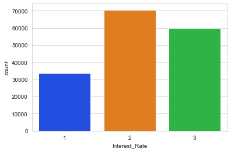

```python
sns.countplot(x='Interest_Rate',data=train,palette='bright');
```

```python
train['Interest_Rate'].value_counts()/train['Interest_Rate'].count()*100
```

```
2    42.955651
3    36.469700
1    20.574649
Name: Interest_Rate, dtype: float64
```

Removing **'comma,'** from **Loan_Amount_Requested** variable.

```python
train['Loan_Amount_Requested']=train['Loan_Amount_Requested'].str.replace(',','')
```

```python
test['Loan_Amount_Requested']=test['Loan_Amount_Requested'].str.replace(',','')
```

```python
train['Loan_Amount_Requested']=train['Loan_Amount_Requested'].astype('int64')
```

```python
test['Loan_Amount_Requested']=test['Loan_Amount_Requested'].astype('int64')
```

# Imputations

On **train** set

**Mode imputations**

```python
statistics.mode(train['Length_Employed'])
```

```
'10+ years'
```

```python
statistics.mode(train['Home_Owner'])
```

```
'Mortgage'
```

```python
train['Length_Employed'].fillna("10+ years",inplace=True)
```

```python
train['Home_Owner'].fillna("Mortgage",inplace=True)
```

**Median imputation**

```python
median(train['Annual_Income'])
```

```
120000.0
```

```python
train['Annual_Income'].fillna(120000.0,inplace=True)
```

On **test** set

**Mode imputations**

```python
statistics.mode(test['Length_Employed'])
```

```
'10+ years'
```

```python
statistics.mode(test['Home_Owner'])
```

```
'Mortgage'
```

```python
test['Length_Employed'].fillna("10+ years",inplace=True)
```

```python
test['Home_Owner'].fillna("Mortgage",inplace=True)
```

**Median imputation**

```python
median(test['Annual_Income'])
```

```
54000.0
```

```python
test['Annual_Income'].fillna(54000.0,inplace=True)
```

There is almost **53%** null values in **Months_Since_Deliquency** variable, we will drop that column from **train** as well **test** set.

```python
train=train.drop(columns=['Months_Since_Deliquency'])
test=test.drop(columns=['Months_Since_Deliquency'])
```

# Feature Engineering

We will create a new attribute **Numner_Invalid_Acc** simply by subtracting **Number_Open_Accounts** from **Total_Accounts**.

```python
train['Number_Invalid_Acc']=train['Total_Accounts'] - train['Number_Open_Accounts']

test['Number_Invalid_Acc']=test['Total_Accounts'] - test['Number_Open_Accounts']
```

By dividing **Loan_Amount_Requested** with **Annual_Income** we will make another attribute that is **Number_Years_To_Repay_Debt**.

```python
train['Number_Years_To_Repay_Debt']=train['Loan_Amount_Requested']/train['Annual_Income']

test['Number_Years_To_Repay_Debt']=test['Loan_Amount_Requested']/test['Annual_Income']
```

# Label encoding

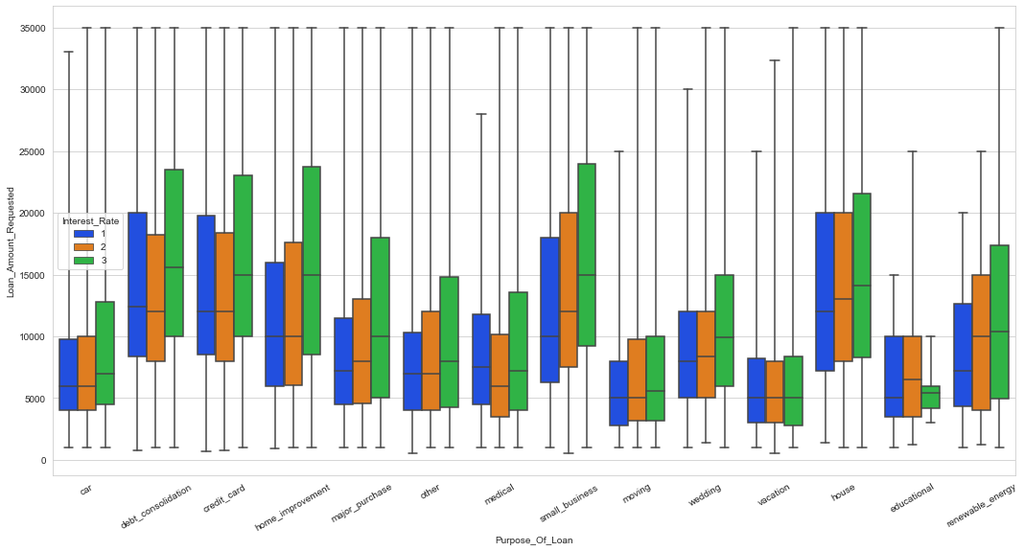

```python
f,ax=plt.subplots(figsize=(18,9))
g=sns.boxplot(x='Purpose_Of_Loan',y='Loan_Amount_Requested',hue='Interest_Rate',data=train,palette='bright',whis=np.inf);
ax.set_xticklabels(ax.get_xticklabels(),rotation=30);
```

We see **debt_consolidation, credit_card, home_improvement, small_business** and **house** these are purposes of loan where the amount requested for loan is quite high as compared to other purposes. So we will put other purposes in one different category.

On **train** set

```python
map_purpose_tr={"car":"not_imp","major_purchase":"not_imp","other":"not_imp","medical":"not_imp",
                "moving":"not_imp","wedding":"not_imp","vacation":"not_imp","educational":"not_imp",
                "renewable_energy":"not_imp",
                "debt_consolidation":"debt_consolidation","credit_card":"credit_card","home_improvement":"home_improvement",
                "small_business":"small_business","house":"house"}
for dataset in train:
    train['Purpose_Of_Loan_New']=train['Purpose_Of_Loan'].map(map_purpose_tr)
```

We will now convert **Length_Employed** attribute to **Ordinal variable**, becuase the length of being employed is **inversely proportional** to the **rate of interest**. If a person is being employed for longer time then bank should give him/her loan on less rate of interest.

```python
map_emp_tr={"10+ years":1,"9 years":2,"8 years":3,"7 years":4,
            "6 years":5,"5 years":6,"4 years":7,"3 years":8,
            "2 years":9,"1 year":10,"< 1 year":11}
for dataset in train:
    train['Length_Employed_New']=train['Length_Employed'].map(map_emp_tr)
```

On **test** set

```python
map_purpose_te={"car":"not_imp","major_purchase":"not_imp","other":"not_imp","medical":"not_imp",
                "moving":"not_imp","wedding":"not_imp","vacation":"not_imp","educational":"not_imp",
                "renewable_energy":"not_imp",
                "debt_consolidation":"debt_consolidation","credit_card":"credit_card","home_improvement":"home_improvement",
                "small_business":"small_business","house":"house"}
for dataset in test:
    test['Purpose_Of_Loan_New']=test['Purpose_Of_Loan'].map(map_purpose_te)
```

```python
map_emp_te={"10+ years":1,"9 years":2,"8 years":3,"7 years":4,
            "6 years":5,"5 years":6,"4 years":7,"3 years":8,
            "2 years":9,"1 year":10,"< 1 year":11}
for dataset in test:
    test['Length_Employed_New']=test['Length_Employed'].map(map_emp_te)
```

```python
train=train.drop(columns=['Purpose_Of_Loan','Length_Employed'])
test=test.drop(columns=['Purpose_Of_Loan','Length_Employed'])
```

# Dummification of categorical variables

On **train** set

```python
dummy_tr_1=pd.get_dummies(train['Income_Verified'],drop_first=True,prefix='Income',prefix_sep='_')
```

```python
dummy_tr_2=pd.get_dummies(train['Purpose_Of_Loan_New'],drop_first=False,prefix='Purpose',prefix_sep='_')
```

```python
dummy_tr_3=pd.get_dummies(train['Home_Owner'],drop_first=True,prefix='Home',prefix_sep='_')
```

```python
train=pd.concat([train,dummy_tr_1,dummy_tr_2,dummy_tr_3],axis=1)
```

```python
train=train.drop(columns=['Income_Verified','Purpose_Of_Loan_New','Purpose_not_imp','Home_Owner'])
```

On **test** set

```python
dummy_te_1=pd.get_dummies(test['Income_Verified'],drop_first=True,prefix='Income',prefix_sep='_')
```

```python
dummy_te_2=pd.get_dummies(test['Purpose_Of_Loan_New'],drop_first=False,prefix='Purpose',prefix_sep='_')
```

```python
dummy_te_3=pd.get_dummies(test['Home_Owner'],drop_first=True,prefix='Home',prefix_sep='_')
```

```python
test=pd.concat([test,dummy_te_1,dummy_te_2,dummy_te_3],axis=1)
```

```python
test=test.drop(columns=['Income_Verified','Purpose_Of_Loan_New','Purpose_not_imp','Home_Owner'])
```

# Setting independent and dependent variables

```python
X=train.drop(columns=['Loan_ID','Interest_Rate','Number_Open_Accounts','Gender'])
y=train['Interest_Rate']
```

# Train - validation split

```python
X_train,X_val,y_train,y_val=train_test_split(X,y,test_size=0.30,
                                             random_state=44)
```

```python
X_train.shape
```

```
(115016, 19)
```

```python
X_train
```

|  | Loan_Amount_Requested | Annual_Income | Debt_To_Income | Inquiries_Last_6Mo | Total_Accounts | Number_Invalid_Acc | Number_Years_To_Repay_Debt | Length_Employed_New | Income_VERIFIED - income source | Income_not verified | Purpose_credit_card | Purpose_debt_consolidation | Purpose_home_improvement | Purpose_house | Purpose_small_business | Home_None | Home_Other | Home_Own | Home_Rent |
| --- | --- | --- | --- | --- | --- | --- | --- | --- | --- | --- | --- | --- | --- | --- | --- | --- | --- | --- | --- |
| 46105 | 21075 | 47000.0 | 23.52 | 0 | 37 | 21 | 0.448404 | 7 | 1 | 0 | 0 | 1 | 0 | 0 | 0 | 0 | 0 | 0 | 1 |
| 44749 | 12000 | 107000.0 | 13.69 | 1 | 43 | 32 | 0.112150 | 1 | 0 | 0 | 0 | 1 | 0 | 0 | 0 | 0 | 0 | 0 | 0 |
| 75456 | 6500 | 89000.0 | 11.68 | 0 | 19 | 8 | 0.073034 | 6 | 0 | 1 | 0 | 1 | 0 | 0 | 0 | 0 | 0 | 0 | 0 |
| 78247 | 22000 | 490000.0 | 6.69 | 0 | 28 | 15 | 0.044898 | 4 | 0 | 0 | 0 | 1 | 0 | 0 | 0 | 0 | 0 | 0 | 0 |
| 143629 | 15000 | 72000.0 | 27.12 | 0 | 41 | 12 | 0.208333 | 2 | 0 | 1 | 0 | 1 | 0 | 0 | 0 | 0 | 0 | 0 | 1 |
| ... | ... | ... | ... | ... | ... | ... | ... | ... | ... | ... | ... | ... | ... | ... | ... | ... | ... | ... | ... |
| 135252 | 9000 | 82200.0 | 25.77 | 0 | 19 | 5 | 0.109489 | 8 | 0 | 1 | 1 | 0 | 0 | 0 | 0 | 0 | 0 | 0 | 0 |
| 116832 | 20000 | 88000.0 | 10.77 | 5 | 20 | 9 | 0.227273 | 10 | 0 | 0 | 0 | 0 | 0 | 0 | 1 | 0 | 0 | 0 | 1 |
| 49723 | 10000 | 90000.0 | 23.52 | 1 | 47 | 30 | 0.111111 | 3 | 0 | 1 | 0 | 0 | 1 | 0 | 0 | 0 | 0 | 0 | 0 |
| 156845 | 10000 | 120000.0 | 21.62 | 1 | 33 | 14 | 0.083333 | 5 | 0 | 0 | 1 | 0 | 0 | 0 | 0 | 0 | 0 | 0 | 0 |
| 14100 | 19000 | 60000.0 | 16.38 | 0 | 19 | 10 | 0.316667 | 9 | 0 | 1 | 0 | 1 | 0 | 0 | 0 | 0 | 0 | 0 | 1 |

115016 rows × 19 columns

# Feature Scale

The Standard Scaler converts your data in a **normally distributed** way, each feature will be scaled such that the distribution is now **centred around 0**, with a **standard deviation of 1**

```python
sc_X=StandardScaler()
X_train=sc_X.fit_transform(X_train)
X_val=sc_X.transform(X_val)
```

```python
X_train
```

```
array([[ 0.81317853, -0.6250192 ,  0.80380159, ..., -0.01793873,
        -0.28769513,  1.38939505],
       [-0.28330746,  0.4999373 , -0.44848806, ..., -0.01793873,
        -0.28769513, -0.7197377 ],
       [-0.94784442,  0.16245035, -0.70455135, ..., -0.01793873,
        -0.28769513, -0.7197377 ],
       ...,
       [-0.52495726,  0.18119963,  0.80380159, ..., -0.01793873,
        -0.28769513, -0.7197377 ],
       [-0.52495726,  0.74367788,  0.56175171, ..., -0.01793873,
        -0.28769513, -0.7197377 ],
       [ 0.56246686, -0.38127862, -0.10579638, ..., -0.01793873,
        -0.28769513,  1.38939505]])
```

# Modelling - Default Parameters

## Naive Bayes

```python
NB=GaussianNB()
NB.fit(X_train,y_train)
y_pred_NB_tr=NB.predict(X_train)
y_pred_NB_val=NB.predict(X_val)

f1_nb_tr=f1_score(y_train,y_pred_NB_tr,average='weighted')
f1_nb_val=f1_score(y_val,y_pred_NB_val,average='weighted')
```

```python
print('Train F1-Score')
print(f1_nb_tr*100)
print('Validation F1-Score')
print(f1_nb_val*100)
```

```
Train F1-Score
41.20190416522384
Validation F1-Score
41.0943921406706
```

## Logistic Regression

```python
LR=LogisticRegression()
LR.fit(X_train,y_train)
y_pred_LR_tr=LR.predict(X_train)
y_pred_LR_val=LR.predict(X_val)

f1_lr_tr=f1_score(y_train,y_pred_LR_tr,average='weighted')
f1_lr_val=f1_score(y_val,y_pred_LR_val,average='weighted')
```

```python
print('Train F1-Score')
print(f1_lr_tr*100)
print('Validation F1-Score')
print(f1_lr_val*100)
```

```
Train F1-Score
40.09298625830404
Validation F1-Score
39.61011386769345
```

## KNN

```python
KNN=KNeighborsClassifier()
KNN.fit(X_train,y_train)
y_pred_KNN_tr=KNN.predict(X_train)
y_pred_KNN_val=KNN.predict(X_val)

f1_knn_tr=f1_score(y_train,y_pred_KNN_tr,average='weighted')
f1_knn_val=f1_score(y_val,y_pred_KNN_val,average='weighted')
```

```python
print('Train F1-Score')
print(f1_knn_tr*100)
print('Validation F1-Score')
print(f1_knn_val*100)
```

```
Train F1-Score
63.14888802692865
Validation F1-Score
44.77640037269469
```

## Decision Tree

```python
DT=DecisionTreeClassifier()
DT.fit(X_train,y_train)
y_pred_DT_tr=DT.predict(X_train)
y_pred_DT_val=DT.predict(X_val)

f1_dt_tr=f1_score(y_train,y_pred_DT_tr,average='weighted')
f1_dt_val=f1_score(y_val,y_pred_DT_val,average='weighted')
```

```python
print('Train F1-Score')
print(f1_dt_tr*100)
print('Validation F1-Score')
print(f1_dt_val*100)
```

```
Train F1-Score
100.0
Validation F1-Score
41.791966110201166
```

## SVC

```python
SVC=SVC()
SVC.fit(X_train,y_train)
y_pred_SVC_tr=SVC.predict(X_train)
y_pred_SVC_val=SVC.predict(X_val)

f1_svc_tr=f1_score(y_train,y_pred_SVC_tr,average='weighted')
f1_svc_val=f1_score(y_val,y_pred_SVC_val,average='weighted')
```

```python
print('Train F1-Score')
print(f1_svc_tr*100)
print('Validation F1-Score')
print(f1_svc_val*100)
```

```
Train F1-Score
47.71807909090837
Validation F1-Score
46.64466018169711
```

## Random Forest

```python
RF=RandomForestClassifier()
RF.fit(X_train,y_train)
y_pred_RF_tr=RF.predict(X_train)
y_pred_RF_val=RF.predict(X_val)

f1_rf_tr=f1_score(y_train,y_pred_RF_tr,average='weighted')
f1_rf_val=f1_score(y_val,y_pred_RF_val,average='weighted')
```

```python
print('Train F1-Score')
print(f1_rf_tr*100)
print('Validation F1-Score')
print(f1_rf_val*100)
```

```
Train F1-Score
100.0
Validation F1-Score
48.21839337436639
```

## Gradient Boosting

```python
GB=GradientBoostingClassifier(learning_rate=0.03,n_estimators=550,subsample=0.8,max_depth=6)
GB.fit(X_train,y_train)
y_pred_GB_val=GB.predict(X_val)
y_pred_GB_tr=GB.predict(X_train)

f1_gb_val=f1_score(y_val,y_pred_GB_val,average='weighted')
f1_gb_tr=f1_score(y_train,y_pred_GB_tr,average='weighted')
```

```python
print('Train F1-Score')
print(f1_gb_tr*100)
print('Validation F1-Score')
print(f1_gb_val*100)
```

```
Train F1-Score
57.22149756907544
Validation F1-Score
50.93931264733153
```

## XGBoost

```python
XGB=xgb.XGBClassifier(subsample=0.8,objective='muliclass:softmax',num_class=3,nthread=4,
                      colsample_bytree=0.8,learning_rate=0.05,n_estimators=100)
XGB.fit(X_train,y_train)
y_pred_XGB_val=XGB.predict(X_val)
y_pred_XGB_tr=XGB.predict(X_train)

f1_xgb_val=f1_score(y_val,y_pred_XGB_val,average='weighted')
f1_xgb_tr=f1_score(y_train,y_pred_XGB_tr,average='weighted')
```

```python
print('Train F1-Score')
print(f1_xgb_tr*100)
print('Validation F1-Score')
print(f1_xgb_val*100)
```

```
Train F1-Score
51.49975266191754
Validation F1-Score
49.28630068400264
```

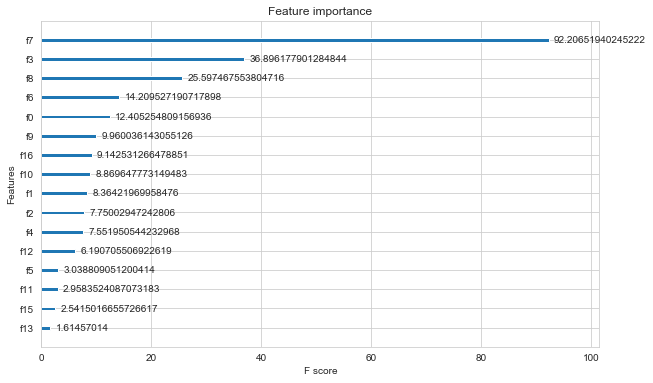

```python
fig,ax=plt.subplots(figsize=(10,6))
xgb.plot_importance(XGB,max_num_features=30,ax=ax,importance_type='gain');
```

## ADABoost

```python
ADA=AdaBoostClassifier(learning_rate=0.03,random_state=44,n_estimators=1000)
ADA.fit(X_train,y_train)
y_pred_ADA_val=ADA.predict(X_val)
y_pred_ADA_tr=ADA.predict(X_train)

f1_ada_val=f1_score(y_val,y_pred_ADA_val,average='weighted')
f1_ada_tr=f1_score(y_train,y_pred_ADA_tr,average='weighted')
```

```python
print('Train F1-Score')
print(f1_ada_tr*100)
print('Validation F1-Score')
print(f1_ada_val*100)
```

```
Train F1-Score
47.595406228074296
Validation F1-Score
47.02433835143948
```

## CatBoost

CatBoost is a machine learning algorithm that uses **gradient boosting on decision trees**.

```python
CB=CatBoostClassifier(max_depth=6,n_estimators=10000)
CB.fit(X_train,y_train)
y_pred_CB_val=CB.predict(X_val)
y_pred_CB_tr=CB.predict(X_train)

f1_cb_val=f1_score(y_val,y_pred_CB_val,average='weighted')
f1_cb_tr=f1_score(y_train,y_pred_CB_tr,average='weighted')
```

[output not shown]

[output cut: 9946 more lines]

[output not shown]

```python
print('Train F1-Score')
print(f1_cb_tr*100)
print('Validation F1-Score')
print(f1_cb_val*100)
```

```
Train F1-Score
57.68250729673278
Validation F1-Score
50.67129026133384
```

## LightGBM

```python
LGBM=LGBMClassifier(max_depth=7,n_estimators=500)
LGBM.fit(X_train,y_train)
y_pred_LGBM_val=LGBM.predict(X_val)
y_pred_LGBM_tr=LGBM.predict(X_train)

f1_lgbm_val=f1_score(y_val,y_pred_LGBM_val,average='weighted')
f1_lgbm_tr=f1_score(y_train,y_pred_LGBM_tr,average='weighted')
```

```python
print('Train F1-Score')
print(f1_lgbm_tr*100)
print('Validation F1-Score')
print(f1_lgbm_val*100)
```

```
Train F1-Score
58.328704415569035
Validation F1-Score
50.816732347131556
```

We will use **Gradient Boosting, Cat Boost** and **Light GB0**M in **Stacking** and **Ensemble Voting** classifiers.

## Ensemble Voting Classifier

```python
CB=CatBoostClassifier(max_depth=6,n_estimators=10000)
LGBM=LGBMClassifier(max_depth=7,n_estimators=500)
GB=GradientBoostingClassifier(learning_rate=0.03,n_estimators=550,subsample=0.80,max_depth=6)

EVC=EnsembleVoteClassifier(clfs=[GB,CB,LGBM],voting='soft')

EVC.fit(X_train,y_train)
y_pred_EVC_val=EVC.predict(X_val)
y_pred_EVC_tr=EVC.predict(X_train)

f1_evc_val=f1_score(y_val,y_pred_EVC_val,average='weighted')
f1_evc_tr=f1_score(y_train,y_pred_EVC_tr,average='weighted')
```

[output not shown]

[output cut: 9946 more lines]

[output not shown]

```python
print('Train F1-Score')
print(f1_evc_tr*100)
print('Validation F1-Score')
print(f1_evc_val*100)
```

```
Train F1-Score
58.11168733665486
Validation F1-Score
50.94864980835191
```

## Sacking

```python
CB=CatBoostClassifier(max_depth=6,n_estimators=10000)
LGBM=LGBMClassifier(max_depth=7,n_estimators=500)
GB=GradientBoostingClassifier(learning_rate=0.03,n_estimators=550,subsample=0.80,max_depth=6)
LR=LogisticRegression()

Stack=StackingClassifier(classifiers=[LGBM,CB,GB],
                                      meta_classifier=LR)

Stack.fit(X_train,y_train)
y_pred_st_val=Stack.predict(X_val)
y_pred_st_tr=Stack.predict(X_train)

f1_st_val=f1_score(y_val,y_pred_st_val,average='weighted')
f1_st_tr=f1_score(y_train,y_pred_st_tr,average='weighted')
```

[output not shown]

[output cut: 9946 more lines]

[output not shown]

```python
print('Train F1-Score')
print(f1_st_tr*100)
print('Validation F1-Score')
print(f1_st_val*100)
```

```
Train F1-Score
57.29845700335168
Validation F1-Score
50.524289081422324
```

## ANN

```python
import keras
from keras.models import Sequential
from keras.layers import Dense
from keras.layers import Dropout
from keras.layers import Flatten
```

**Preprocessing**

```python
# For encoding the Target
from sklearn.preprocessing import OneHotEncoder

onehotencoder=OneHotEncoder(handle_unknown='ignore')
# Fit on Train
OneHotEncoder=onehotencoder.fit(y_train.values.reshape(-1, 1))

# Transform on Validation and Train
OneHotEncoder_target_train_nn=OneHotEncoder.transform(y_train.values.reshape(-1, 1)).toarray()
OneHotEncoder_target_val_nn=OneHotEncoder.transform(y_val.values.reshape(-1, 1)).toarray()

# Check the shape
OneHotEncoder_target_val_nn.shape
```

```
(49293, 3)
```

Defining **Error Metric**

```python
from keras import backend as K
def recall_m(y_true, y_pred):
        true_positives = K.sum(K.round(K.clip(y_true * y_pred, 0, 1)))
        possible_positives = K.sum(K.round(K.clip(y_true, 0, 1)))
        recall = true_positives / (possible_positives + K.epsilon())
        return recall
def precision_m(y_true, y_pred):
        true_positives = K.sum(K.round(K.clip(y_true * y_pred, 0, 1)))
        predicted_positives = K.sum(K.round(K.clip(y_pred, 0, 1)))
        precision = true_positives / (predicted_positives + K.epsilon())
        return precision
def f1_m(y_true, y_pred):
    precision = precision_m(y_true, y_pred)
    recall = recall_m(y_true, y_pred)
    return 2*((precision*recall)/(precision+recall+K.epsilon()))
```

Making **Nueral Network**

```python
classifier_ANN=Sequential()

classifier_ANN.add(Dense(units=150,kernel_initializer='uniform',activation='relu',input_dim=17))
#classifier_ANN.add(Dropout(p=0.2))

classifier_ANN.add(Dense(units=200,kernel_initializer='uniform',activation='relu'))
classifier_ANN.add(Dropout(p=0.2))

classifier_ANN.add(Dense(units=250,kernel_initializer='uniform',activation='relu'))
#classifier_ANN.add(Dropout(p=0.2))

classifier_ANN.add(Dense(units=150,kernel_initializer='uniform',activation='relu'))
classifier_ANN.add(Dropout(p=0.2))

classifier_ANN.add(Dense(units=100,kernel_initializer='uniform',activation='relu'))
#classifier_ANN.add(Dropout(p=0.2))

classifier_ANN.add(Dense(units=50,kernel_initializer='uniform',activation='relu'))
classifier_ANN.add(Dropout(p=0.2))

classifier_ANN.add(Dense(units=10,kernel_initializer='uniform',activation='relu'))
#classifier_ANN.add(Dropout(p=0.1))

#classifier_ANN.add(Flatten())

classifier_ANN.add(Dense(units=3,kernel_initializer='uniform',activation='softmax'))

classifier_ANN.compile(optimizer='adam',loss='categorical_crossentropy',metrics=[f1_m])

classifier_ANN.summary()
```

```
Model: "sequential_4"
_________________________________________________________________
Layer (type)                 Output Shape              Param #
=================================================================
dense_23 (Dense)             (None, 150)               2700
_________________________________________________________________
dense_24 (Dense)             (None, 200)               30200
_________________________________________________________________
dropout_20 (Dropout)         (None, 200)               0
_________________________________________________________________
dense_25 (Dense)             (None, 250)               50250
_________________________________________________________________
dense_26 (Dense)             (None, 150)               37650
_________________________________________________________________
dropout_21 (Dropout)         (None, 150)               0
_________________________________________________________________
dense_27 (Dense)             (None, 100)               15100
_________________________________________________________________
dense_28 (Dense)             (None, 50)                5050
_________________________________________________________________
dropout_22 (Dropout)         (None, 50)                0
_________________________________________________________________
dense_29 (Dense)             (None, 10)                510
_________________________________________________________________
dense_30 (Dense)             (None, 3)                 33
=================================================================
Total params: 141,493
Trainable params: 141,493
Non-trainable params: 0
_________________________________________________________________
```

```python
classifier_ANN.fit(X_train,OneHotEncoder_target_train_nn,validation_data=(X_val,OneHotEncoder_target_val_nn),epochs=100,use_multiprocessing=True,batch_size=80)
```

```
Train on 115016 samples, validate on 49293 samples
```

```
<keras.callbacks.callbacks.History at 0x279d3c5aa48>
```

**Plotting F1 Score of Train-Validation**

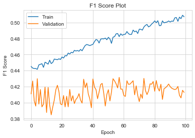

```python
plt.plot(classifier_ANN.history.history['f1_m'])
plt.plot(classifier_ANN.history.history['val_f1_m'])
plt.title('F1 Score Plot')
plt.ylabel('F1 Score')
plt.xlabel('Epoch')
plt.legend(['Train','Validation'])
plt.show()
```

```python
y_pred_val_ann=classifier_ANN.predict(X_val)
y_classes_val_ann=y_pred_val_ann.argmax(axis=1)
```

```python
y_classes_val_ann=y_classes_val_ann+1
np.unique(y_classes_val_ann)
```

```
array([1, 2, 3], dtype=int64)
```

```python
print(classification_report(y_val,y_classes_val_ann))
```

```
              precision    recall  f1-score   support

           1       0.42      0.25      0.31     10115
           2       0.49      0.54      0.51     21179
           3       0.53      0.59      0.56     17999

    accuracy                           0.50     49293
   macro avg       0.48      0.46      0.46     49293
weighted avg       0.49      0.50      0.49     49293
```

# Predicting on **test** set

```python
test_for_prediction=test.drop(columns=['Loan_ID','Number_Open_Accounts','Gender'])
```

```python
test_for_prediction.shape
```

```
(109541, 19)
```

```python
test_for_prediction
```

|  | Loan_Amount_Requested | Annual_Income | Debt_To_Income | Inquiries_Last_6Mo | Total_Accounts | Number_Invalid_Acc | Number_Years_To_Repay_Debt | Length_Employed_New | Income_VERIFIED - income source | Income_not verified | Purpose_credit_card | Purpose_debt_consolidation | Purpose_home_improvement | Purpose_house | Purpose_small_business | Home_None | Home_Other | Home_Own | Home_Rent |
| --- | --- | --- | --- | --- | --- | --- | --- | --- | --- | --- | --- | --- | --- | --- | --- | --- | --- | --- | --- |
| 0 | 27500 | 129000.0 | 12.87 | 0 | 37 | 27 | 0.213178 | 1 | 0 | 0 | 0 | 1 | 0 | 0 | 0 | 0 | 0 | 0 | 0 |
| 1 | 26000 | 110000.0 | 11.37 | 0 | 23 | 17 | 0.236364 | 1 | 0 | 1 | 1 | 0 | 0 | 0 | 0 | 0 | 0 | 0 | 0 |
| 2 | 6075 | 75000.0 | 6.83 | 2 | 20 | 15 | 0.081000 | 11 | 0 | 0 | 0 | 1 | 0 | 0 | 0 | 0 | 0 | 0 | 1 |
| 3 | 12000 | 73000.0 | 7.76 | 0 | 8 | 2 | 0.164384 | 1 | 1 | 0 | 0 | 1 | 0 | 0 | 0 | 0 | 0 | 0 | 0 |
| 4 | 35000 | 156000.0 | 9.62 | 0 | 21 | 12 | 0.224359 | 11 | 0 | 1 | 0 | 1 | 0 | 0 | 0 | 0 | 0 | 0 | 0 |
| ... | ... | ... | ... | ... | ... | ... | ... | ... | ... | ... | ... | ... | ... | ... | ... | ... | ... | ... | ... |
| 109536 | 15000 | 120000.0 | 8.15 | 2 | 57 | 44 | 0.125000 | 2 | 0 | 0 | 0 | 0 | 0 | 0 | 0 | 0 | 0 | 0 | 0 |
| 109537 | 9600 | 125000.0 | 9.08 | 1 | 34 | 25 | 0.076800 | 1 | 0 | 1 | 1 | 0 | 0 | 0 | 0 | 0 | 0 | 0 | 0 |
| 109538 | 2000 | 37850.0 | 11.60 | 0 | 11 | 1 | 0.052840 | 6 | 0 | 1 | 1 | 0 | 0 | 0 | 0 | 0 | 0 | 0 | 1 |
| 109539 | 2125 | 30000.0 | 24.88 | 0 | 6 | 1 | 0.070833 | 5 | 0 | 1 | 0 | 0 | 0 | 0 | 0 | 0 | 0 | 0 | 1 |
| 109540 | 15000 | 137000.0 | 8.66 | 1 | 17 | 9 | 0.109489 | 9 | 0 | 1 | 0 | 0 | 0 | 0 | 0 | 0 | 0 | 0 | 0 |

109541 rows × 19 columns

**Feature Scaling**

```python
sc_test=StandardScaler()
test_for_prediction=sc_test.fit_transform(test_for_prediction)
```

```python
test_for_prediction
```

```
array([[ 1.58335939,  1.13304424, -0.55547555, ..., -0.01655129,
        -0.28733258, -0.72164335],
       [ 1.40263157,  0.76517555, -0.74662473, ..., -0.01655129,
        -0.28733258, -0.72164335],
       [-0.99803625,  0.0875227 , -1.32516956, ..., -0.01655129,
        -0.28733258,  1.38572607],
       ...,
       [-1.48901348, -0.63175739, -0.71731519, ..., -0.01655129,
        -0.28733258,  1.38572607],
       [-1.47395283, -0.78374524,  0.97499216, ..., -0.01655129,
        -0.28733258,  1.38572607],
       [ 0.07729426,  1.28793632, -1.09196757, ..., -0.01655129,
        -0.28733258, -0.72164335]])
```

## Logistic Regression

```python
prediction_LR=LR.predict(test_for_prediction)

submission=pd.DataFrame({"Loan_ID":test["Loan_ID"],"Interest_Rate":prediction_LR})
submission.to_csv('sub_lr.csv',index=False)
```

## Random Forest

```python
prediction_RF=RF.predict(test_for_prediction)

submission=pd.DataFrame({"Loan_ID":test["Loan_ID"],"Interest_Rate":prediction_RF})
submission.to_csv('sub_rf.csv',index=False)
```

## XGBoost

```python
prediction_XGB=XGB.predict(test_for_prediction)

submission=pd.DataFrame({"Loan_ID":test["Loan_ID"],"Interest_Rate":prediction_XGB})
submission.to_csv('sub_xgb.csv',index=False)
```

## Gradient Boosting

```python
prediction_GB=GB.predict(test_for_prediction)

submission=pd.DataFrame({"Loan_ID":test["Loan_ID"],"Interest_Rate":prediction_GB})
submission.to_csv('sub_gb.csv',index=False)
```

## CatBoost

```python
prediction_CB=CB.predict(test_for_prediction)
prediction_CB=prediction_CB.flatten()

submission=pd.DataFrame({"Loan_ID":test["Loan_ID"],"Interest_Rate":prediction_CB})
submission.to_csv('sub_cb.csv',index=False)
```

## LightGBM

```python
prediction_LGBM=LGBM.predict(test_for_prediction)

submission=pd.DataFrame({"Loan_ID":test["Loan_ID"],"Interest_Rate":prediction_LGBM})
submission.to_csv('sub_lgbm.csv',index=False)
```

## ANN

```python
# Make the prediction
y_pred_test_ann=classifier_ANN.predict(test_for_prediction)

y_pred_test_ann=y_pred_test_ann.argmax(axis=1)

y_pred_test_ann=y_pred_test_ann+1

# # Save the predictions
y_pred_test_ann=y_pred_test_ann.tolist()

submission=pd.DataFrame({"Loan_ID":test["Loan_ID"],
                         "Interest_Rate":y_pred_test_ann})
submission.to_csv('sub_ann.csv',index=False)
```

## EVC

```python
prediction_EVC=EVC.predict(test_for_prediction)

submission=pd.DataFrame({"Loan_ID":test["Loan_ID"],"Interest_Rate":prediction_EVC})
submission.to_csv('sub_evc.csv',index=False)
```

## Stacking

```python
prediction_Stack=Stack.predict(test_for_prediction)

submission=pd.DataFrame({"Loan_ID":test["Loan_ID"],"Interest_Rate":prediction_Stack})
submission.to_csv('sub_st.csv',index=False)
```

# Results

Highest **F1-Score weighted** achieved on **test** **Gradient Boosting** classifier which is **51.43**.